# Exploratory data analysis

Irene N. Chang

6/12/2020

knit: (function(input_file, encoding) { out_dir <- ‘docs’; rmarkdown::render(input_file, encoding=encoding, output_file=file.path(dirname(input_file), out_dir, ‘index.html’))})

# What impacts students’ performance?

### Get the data

Load the packages

```r
packages <- c("RCurl","data.table","tidyverse","reshape2", "ggplot2","gridExtra")
sapply(packages, require, character.only=T)
```

```
##      RCurl data.table  tidyverse   reshape2    ggplot2  gridExtra
##       TRUE       TRUE       TRUE       TRUE       TRUE       TRUE
```

What are the files?

```r
path<- getwd()
path <- file.path(path, "Student")
list.files(path)
```

```
## [1] "student-mat.csv" "student-merge.R" "student-por.csv" "student.txt"
```

Reading files

```r
math <- fread(file.path(path,"student-mat.csv"), stringsAsFactors=T)
port <- fread(file.path(path,"student-por.csv"), stringsAsFactors=T)
```

### Manipulate the data

Any missing values?

```r
sum(is.na(data))
```

```
## [1] 0
```

Adding a variable

```r
math$average <- round(apply(select(math, G1, G2, G3), 1, mean), 2)
port$average <- round(apply(select(port, G1, G2, G3), 1, mean), 2)

math$subject<- rep("Math", nrow(math))
port$subject<- rep("Portugese", nrow(port))
```

Combining two datasets

```r
data <- rbind(math, port)
head(data)
```

```
##    school sex age address famsize Pstatus Medu Fedu     Mjob     Fjob
## 1:     GP   F  18       U     GT3       A    4    4  at_home  teacher
## 2:     GP   F  17       U     GT3       T    1    1  at_home    other
## 3:     GP   F  15       U     LE3       T    1    1  at_home    other
## 4:     GP   F  15       U     GT3       T    4    2   health services
## 5:     GP   F  16       U     GT3       T    3    3    other    other
## 6:     GP   M  16       U     LE3       T    4    3 services    other
##        reason guardian traveltime studytime failures schoolsup famsup paid
## 1:     course   mother          2         2        0       yes     no   no
## 2:     course   father          1         2        0        no    yes   no
## 3:      other   mother          1         2        3       yes     no  yes
## 4:       home   mother          1         3        0        no    yes  yes
## 5:       home   father          1         2        0        no    yes  yes
## 6: reputation   mother          1         2        0        no    yes  yes
##    activities nursery higher internet romantic famrel freetime goout Dalc
## 1:         no     yes    yes       no       no      4        3     4    1
## 2:         no      no    yes      yes       no      5        3     3    1
## 3:         no     yes    yes      yes       no      4        3     2    2
## 4:        yes     yes    yes      yes      yes      3        2     2    1
## 5:         no     yes    yes       no       no      4        3     2    1
## 6:        yes     yes    yes      yes       no      5        4     2    1
##    Walc health absences G1 G2 G3 average subject
## 1:    1      3        6  5  6  6    5.67    Math
## 2:    1      3        4  5  5  6    5.33    Math
## 3:    3      3       10  7  8 10    8.33    Math
## 4:    1      5        2 15 14 15   14.67    Math
## 5:    2      5        4  6 10 10    8.67    Math
## 6:    2      5       10 15 15 15   15.00    Math
```

#### Tidy variables

Support categories

```r
data$support <- "0"
data[schoolsup=="yes"& famsup=="yes"]$support<- "both"
data[schoolsup=="yes"& famsup!="yes"]$support<- "school"
data[schoolsup!="yes"& famsup=="yes"]$support<- "family"
data[schoolsup!="yes"& famsup!="yes"]$support<- "none"
data$support <- as.factor(data$support)
data <- select(data, -c("schoolsup","famsup"))
```

Split the data set to analyze

Family set

```
##    famsize Pstatus Medu Fedu     Mjob     Fjob guardian famrel G1 G2 G3
## 1:     GT3       A    4    4  at_home  teacher   mother      4  5  6  6
## 2:     GT3       T    1    1  at_home    other   father      5  5  5  6
## 3:     LE3       T    1    1  at_home    other   mother      4  7  8 10
## 4:     GT3       T    4    2   health services   mother      3 15 14 15
## 5:     GT3       T    3    3    other    other   father      4  6 10 10
## 6:     LE3       T    4    3 services    other   mother      5 15 15 15
##    average subject
## 1:    5.67    Math
## 2:    5.33    Math
## 3:    8.33    Math
## 4:   14.67    Math
## 5:    8.67    Math
## 6:   15.00    Math
```

Personal set

```
##    school sex age address     reason traveltime studytime failures paid
## 1:     GP   F  18       U     course          2         2        0   no
## 2:     GP   F  17       U     course          1         2        0   no
## 3:     GP   F  15       U      other          1         2        3  yes
## 4:     GP   F  15       U       home          1         3        0  yes
## 5:     GP   F  16       U       home          1         2        0  yes
## 6:     GP   M  16       U reputation          1         2        0  yes
##    activities nursery higher internet romantic freetime goout Dalc Walc
## 1:         no     yes    yes       no       no        3     4    1    1
## 2:         no      no    yes      yes       no        3     3    1    1
## 3:         no     yes    yes      yes       no        3     2    2    3
## 4:        yes     yes    yes      yes      yes        2     2    1    1
## 5:         no     yes    yes       no       no        3     2    1    2
## 6:        yes     yes    yes      yes       no        4     2    1    2
##    health absences G1 G2 G3 average subject support
## 1:      3        6  5  6  6    5.67    Math  school
## 2:      3        4  5  5  6    5.33    Math  family
## 3:      3       10  7  8 10    8.33    Math  school
## 4:      5        2 15 14 15   14.67    Math  family
## 5:      5        4  6 10 10    8.67    Math  family
## 6:      5       10 15 15 15   15.00    Math  family
```

Is there a relationship between the three exams?

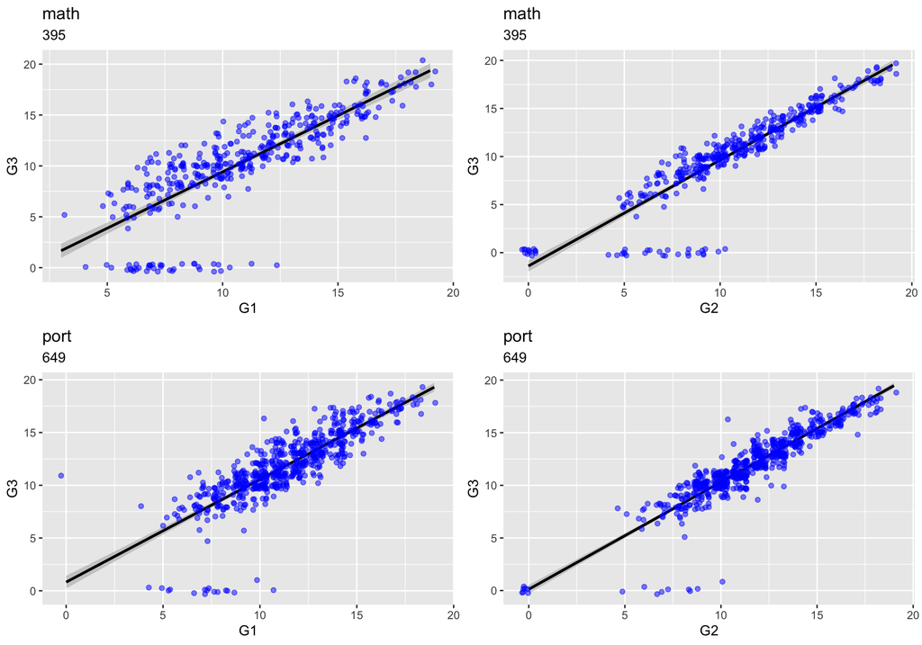

The first and second period grade both positively correlate with the final grade. In addition, the second period grade seems to be a slightly better indicator of the final grade.

Therefore, knowing what affects G1 and G2 can help us learn what impacts that final results.

In this part, we examine family-related factors.

#### **1. FAMILY SIZE AND PARENTAL STATUS**

Firstly, consider the family dataset. Let’s see if family size affects a student’s grade

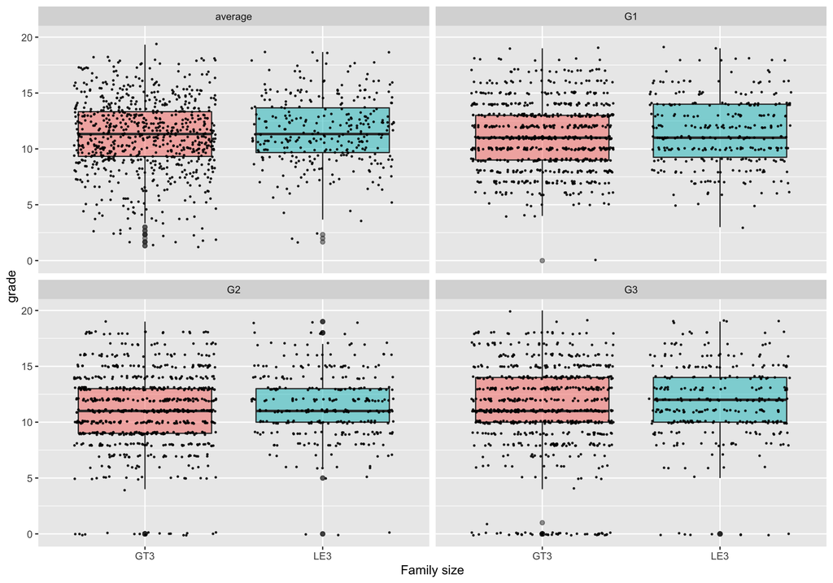

How about parental status?

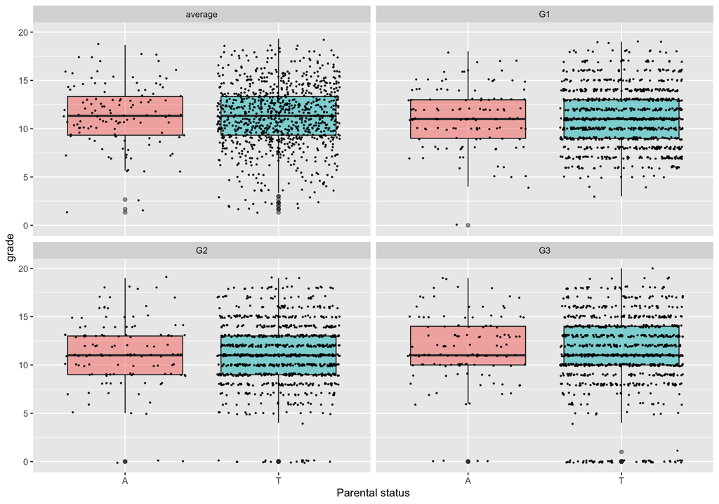

```r
t.test(average~famsize,data=family, var.equal=T, alternative="greater")
##P-value=0.9772
t.test(average~Pstatus,data=family, var.equal=T, alternative="greater")
##Pvalue=0.3048
```

The difference is not significant.

There isn’t much difference in the average grade between a child whose parents are apart and that with parents living together. The same conclusion can be drawn between students living in family with more than 3 people and students living with fewer than or equal to 3 people. Hence, parental status and family size don’t impact the grade in a significant way.

Notice that there are a quite a few students with 0 mark in their final exam in family with parents living together, in comparison to students with separated parents. The same trend is observed in family of size greater than 3 as opposed to family with less than or equal to 3 members. We do a brief examination.

```r
prop.test(x=c(50,4), n=c(923,121), correct=T)
```

```
##
##  2-sample test for equality of proportions with continuity
##  correction
##
## data:  c(50, 4) out of c(923, 121)
## X-squared = 0.58943, df = 1, p-value = 0.4426
## alternative hypothesis: two.sided
## 95 percent confidence interval:
##  -0.01860424  0.06083090
## sample estimates:
##     prop 1     prop 2
## 0.05417118 0.03305785
```

```r
prop.test(x=c(45,9), n=c(738,306), correct=T)
```

```
##
##  2-sample test for equality of proportions with continuity
##  correction
##
## data:  c(45, 9) out of c(738, 306)
## X-squared = 3.7737, df = 1, p-value = 0.05206
## alternative hypothesis: two.sided
## 95 percent confidence interval:
##  0.003631887 0.059495803
## sample estimates:
##     prop 1     prop 2
## 0.06097561 0.02941176
```

Regarding proportions, the proportion of students with 0 mark on the final exam whose parents live together does not differ significantly from that of students whose parents are separate. This is also true for both famsize categories.

Through the graphs above, we can also see that students have greater difficuty in the second period than in the first one, which by far makes sense as the level of difficulty would usually goes up towards the end of year.

Now that famzise and parental status don’t contribute much to our finding, let’s move on to the next elements.

#### **2. MOTHER’S AND FATHER’S JOB**

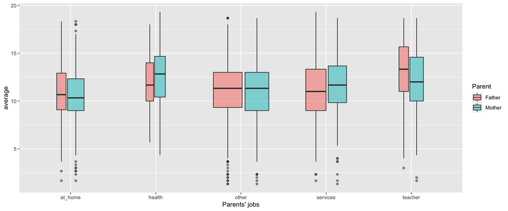

```r
kruskal.test(average~Mjob, family)
```

```
##
##  Kruskal-Wallis rank sum test
##
## data:  average by Mjob
## Kruskal-Wallis chi-squared = 41.254, df = 4, p-value = 2.381e-08
```

```r
pairwise.wilcox.test(family$average, family$Mjob, p.adjust.method = "BH")
```

```
##
##  Pairwise comparisons using Wilcoxon rank sum test
##
## data:  family$average and family$Mjob
##
##          at_home health  other   services
## health   1.2e-05 -       -       -
## other    0.02937 0.00027 -       -
## services 0.00017 0.03358 0.03871 -
## teacher  1.2e-05 0.50467 0.00107 0.16099
##
## P value adjustment method: BH
```

The average scores differ according to the mother’s jobs. Students whose mother is a **housemaker** tend to have lower score than all of their their counterparts, and those whose mother works in **health** industry tend to have higher scores than most of their counterparts.

```r
kruskal.test(average~Fjob, family)
```

```
##
##  Kruskal-Wallis rank sum test
##
## data:  average by Fjob
## Kruskal-Wallis chi-squared = 22.169, df = 4, p-value = 0.0001854
```

```r
pairwise.wilcox.test(family$average, family$Fjob, p.adjust.method = "BH")
```

```
##
##  Pairwise comparisons using Wilcoxon rank sum test
##
## data:  family$average and family$Fjob
##
##          at_home health  other   services
## health   0.22982 -       -       -
## other    0.64958 0.22982 -       -
## services 0.68690 0.22982 0.79438 -
## teacher  0.00150 0.16550 0.00012 0.00016
##
## P value adjustment method: BH
```

The average scores differ according to the father’s jobs.Students whose father is a **teacher** tends to have higher average score than all others.

#### **3. MOTHER’S AND FATHER’S EDUCATION**

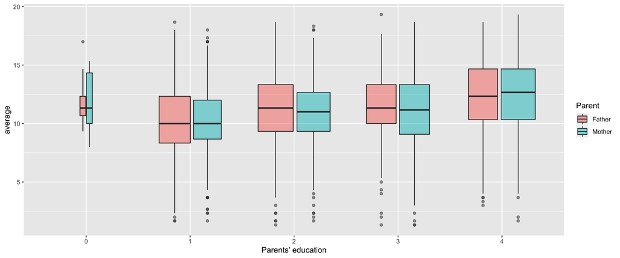

```r
kruskal.test(average~Medu, family)
```

```
##
##  Kruskal-Wallis rank sum test
##
## data:  average by Medu
## Kruskal-Wallis chi-squared = 70.43, df = 4, p-value = 1.842e-14
```

```r
pairwise.wilcox.test(family$average, family$Medu, p.adjust.method = "BH")
```

```
##
##  Pairwise comparisons using Wilcoxon rank sum test
##
## data:  family$average and family$Medu
##
##   0     1       2       3
## 1 0.212 -       -       -
## 2 0.683 0.002   -       -
## 3 0.698 0.002   0.683   -
## 4 0.536 2.6e-14 4.9e-08 2.2e-05
##
## P value adjustment method: BH
```

```r
kruskal.test(average~Fedu, family)
```

```
##
##  Kruskal-Wallis rank sum test
##
## data:  average by Fedu
## Kruskal-Wallis chi-squared = 48.589, df = 4, p-value = 7.112e-10
```

```r
pairwise.wilcox.test(family$average, family$Fedu, p.adjust.method = "BH")
```

```
##
##  Pairwise comparisons using Wilcoxon rank sum test
##
## data:  family$average and family$Fedu
##
##   0       1       2       3
## 1 0.17823 -       -       -
## 2 0.73826 0.00054 -       -
## 3 0.79704 5.5e-05 0.61558 -
## 4 0.61558 4.7e-10 0.00071 0.00666
##
## P value adjustment method: BH
```

Students whose parents’ education is at **primary** level tend to have significantly lover average score than others, and students whose parents reach **higher** education have significantly higher average score.

#### **4. FAMILY RELATIONSHIP**

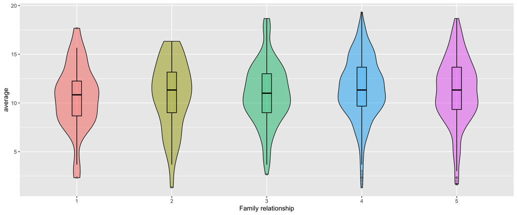

```r
kruskal.test(average~famrel, family)
```

```
##
##  Kruskal-Wallis rank sum test
##
## data:  average by famrel
## Kruskal-Wallis chi-squared = 6.7394, df = 4, p-value = 0.1503
```

P-value is large, indicating that family relationship doesn’t imply much about a student’s performance.

### Takeaways:

- Parents’ education and parents’ jobs are main indicator of a student’s overall performance.
- Between the two factor, education factor confirms an common presumption that children will benefit from parents with a degree in higher education. Meanwhile, the job factor reveals more interesting information that the students who have mother working in health industry and father working as teachers tend to perform better overall.